# Data Visualisation Masterclass: Plots & Charts

This part of the Data Visualisation Masterclass is intended to discuss some very basic techniques to visualise tabular data, i.e. data arranged in a table. We will refer to columns in the table as dimensions or variables, and to rows of the table as items or data points. To see the code that produces all figures, hit the dropdown box at the top right of this document and pick ‘Download Rmd’.

## Setup

To setup, we need to load the required libraries and setup our example data:

```r
library(ggplot2)
theme_set(theme_bw() + theme(panel.grid.major = element_blank(), panel.grid.minor = element_blank(), panel.border = element_blank()))
library(dplyr)
data <- mtcars %>%
  select(Economy = mpg, Cylinders = cyl, Displacement = disp, Horsepower = hp, Weight = wt, Acceleration = qsec, Transmission = am) %>%
  mutate(Transmission = plyr::revalue(factor(Transmission), c("0" = "Automatic", "1" = "Manual"))) %>%
  mutate(Name = as.factor(rownames(mtcars)))
rownames(data) <- rownames(mtcars)
```

Our toy data for this course is the classical car data, slightly modified to be more human readable:

```r
knitr::kable(data)
```

|  | Economy | Cylinders | Displacement | Horsepower | Weight | Acceleration | Transmission | Name |
| --- | --- | --- | --- | --- | --- | --- | --- | --- |
| Mazda RX4 | 21.0 | 6 | 160.0 | 110 | 2.620 | 16.46 | Manual | Mazda RX4 |
| Mazda RX4 Wag | 21.0 | 6 | 160.0 | 110 | 2.875 | 17.02 | Manual | Mazda RX4 Wag |
| Datsun 710 | 22.8 | 4 | 108.0 | 93 | 2.320 | 18.61 | Manual | Datsun 710 |
| Hornet 4 Drive | 21.4 | 6 | 258.0 | 110 | 3.215 | 19.44 | Automatic | Hornet 4 Drive |
| Hornet Sportabout | 18.7 | 8 | 360.0 | 175 | 3.440 | 17.02 | Automatic | Hornet Sportabout |
| Valiant | 18.1 | 6 | 225.0 | 105 | 3.460 | 20.22 | Automatic | Valiant |
| Duster 360 | 14.3 | 8 | 360.0 | 245 | 3.570 | 15.84 | Automatic | Duster 360 |
| Merc 240D | 24.4 | 4 | 146.7 | 62 | 3.190 | 20.00 | Automatic | Merc 240D |
| Merc 230 | 22.8 | 4 | 140.8 | 95 | 3.150 | 22.90 | Automatic | Merc 230 |
| Merc 280 | 19.2 | 6 | 167.6 | 123 | 3.440 | 18.30 | Automatic | Merc 280 |
| Merc 280C | 17.8 | 6 | 167.6 | 123 | 3.440 | 18.90 | Automatic | Merc 280C |
| Merc 450SE | 16.4 | 8 | 275.8 | 180 | 4.070 | 17.40 | Automatic | Merc 450SE |
| Merc 450SL | 17.3 | 8 | 275.8 | 180 | 3.730 | 17.60 | Automatic | Merc 450SL |
| Merc 450SLC | 15.2 | 8 | 275.8 | 180 | 3.780 | 18.00 | Automatic | Merc 450SLC |
| Cadillac Fleetwood | 10.4 | 8 | 472.0 | 205 | 5.250 | 17.98 | Automatic | Cadillac Fleetwood |
| Lincoln Continental | 10.4 | 8 | 460.0 | 215 | 5.424 | 17.82 | Automatic | Lincoln Continental |
| Chrysler Imperial | 14.7 | 8 | 440.0 | 230 | 5.345 | 17.42 | Automatic | Chrysler Imperial |
| Fiat 128 | 32.4 | 4 | 78.7 | 66 | 2.200 | 19.47 | Manual | Fiat 128 |
| Honda Civic | 30.4 | 4 | 75.7 | 52 | 1.615 | 18.52 | Manual | Honda Civic |
| Toyota Corolla | 33.9 | 4 | 71.1 | 65 | 1.835 | 19.90 | Manual | Toyota Corolla |
| Toyota Corona | 21.5 | 4 | 120.1 | 97 | 2.465 | 20.01 | Automatic | Toyota Corona |
| Dodge Challenger | 15.5 | 8 | 318.0 | 150 | 3.520 | 16.87 | Automatic | Dodge Challenger |
| AMC Javelin | 15.2 | 8 | 304.0 | 150 | 3.435 | 17.30 | Automatic | AMC Javelin |
| Camaro Z28 | 13.3 | 8 | 350.0 | 245 | 3.840 | 15.41 | Automatic | Camaro Z28 |
| Pontiac Firebird | 19.2 | 8 | 400.0 | 175 | 3.845 | 17.05 | Automatic | Pontiac Firebird |
| Fiat X1-9 | 27.3 | 4 | 79.0 | 66 | 1.935 | 18.90 | Manual | Fiat X1-9 |
| Porsche 914-2 | 26.0 | 4 | 120.3 | 91 | 2.140 | 16.70 | Manual | Porsche 914-2 |
| Lotus Europa | 30.4 | 4 | 95.1 | 113 | 1.513 | 16.90 | Manual | Lotus Europa |
| Ford Pantera L | 15.8 | 8 | 351.0 | 264 | 3.170 | 14.50 | Manual | Ford Pantera L |
| Ferrari Dino | 19.7 | 6 | 145.0 | 175 | 2.770 | 15.50 | Manual | Ferrari Dino |
| Maserati Bora | 15.0 | 8 | 301.0 | 335 | 3.570 | 14.60 | Manual | Maserati Bora |
| Volvo 142E | 21.4 | 4 | 121.0 | 109 | 2.780 | 18.60 | Manual | Volvo 142E |

## Dotplot

The dotplot is probably the most straight-forward plot for a single, quantitative variable and simply maps a point to every data value along a common scale:

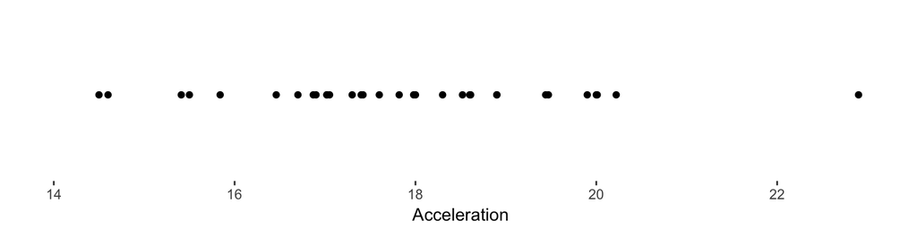

```r
dotplot <- ggplot(data, aes(x = Acceleration, y = 5)) + geom_point(show.legend = F) + theme(axis.ticks.y = element_blank(), axis.text.y = element_blank(), axis.title.y = element_blank()) + xlim(14,23)
dotplot
```

## Boxplot

Boxplot or Box-and-whisker-plots show some basic statistical properties of samples from a variable: the median is mapped to a line, the inter-quartile range to the length of a rectangle, and outliers to individual points:

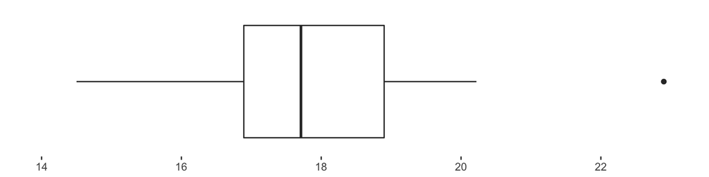

```r
boxplot <- ggplot(data, aes(x = "", y = Acceleration)) + geom_boxplot() + ylim(14,23) + theme(axis.title.x = element_blank(), axis.ticks.y = element_blank(), axis.title = element_blank(), axis.text.y = element_blank()) + coord_flip()
boxplot
```

Boxplots are very useful to visually summarise the *distribution* of values in our sample.

## Histogram

Probably the most common way to visualise the counts and distributions of variables is a histogram. Here, a user-defined number of equally sized bins is used to count all occurences of values in those bins, and visualise the *count* mapped to the height of a bar:

```r
histogram_default <- ggplot(data, aes(Acceleration)) + geom_histogram(binwidth = 1) + scale_x_continuous(breaks = c(14,16,18,20,24)) + xlim(14,24)
histogram_default
```

[output not shown]

This is a very effective way to visualise quantitative data, since humans can most accurately compare values if mapped to a *length on a common scale*. However, it’s important to understand that not only the bin-width, but also the position or shift of the bins is crucial in determining the final pattern - and its interpretation:

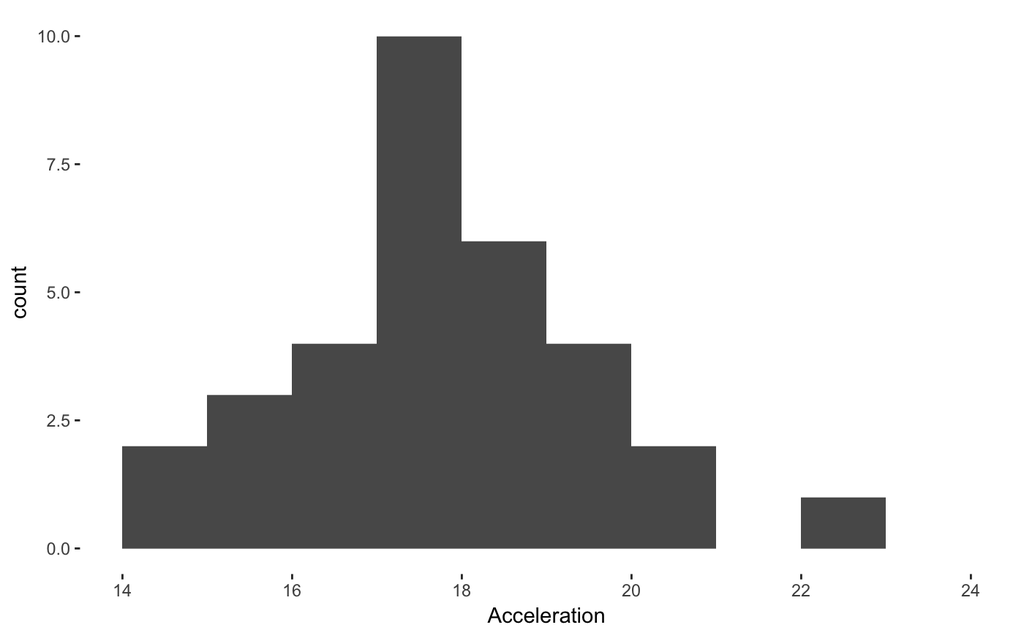

```r
histogram <- ggplot(data, aes(Acceleration)) + geom_histogram(breaks = c(seq(14,24))) + scale_x_continuous(breaks = c(14,16,18,20,24)) + xlim(14,24)
histogram <- ggplot(data, aes(Acceleration)) + geom_histogram(breaks = c(seq(14,24))) + scale_x_continuous(breaks = c(14,16,18,20,24)) + xlim(14,24)
histogram
```

## Density Plot

Decreasing the binsize to infinitely narrow bin, we can obtain a continuous model of a density distribution, and map its values to a smooth line:

```r
histogram_scaled <- ggplot(data, aes(Acceleration, ..density..)) + geom_histogram(breaks = c(seq(14,24))) + scale_x_continuous(breaks = c(14,16,18,20,24)) + xlim(14,24)

histogram_density <- histogram_scaled + geom_density(aes(color = "red"), show.legend = F)
histogram_density
```

[output not shown]

These plots are often referred to as *kernel density estimates* (KDEs), because - similar to the binsize - they require a *kernel* (typically Gaussian) to model individual samples as continuous distributions and compute the final density from all samples. In fact, the histogram using rectangular bins is a special case of a KDE, using a rectangular kernel.

## Violin Plot

By mirroring the smooth density distribution along the horizontal axis, we obtain a *violin plot*:

```r
violin <- ggplot(data, aes(x = "", y = Acceleration)) + geom_violin() + ylim(14,24) + theme(axis.title.x = element_blank(), axis.ticks.y = element_blank(), axis.title = element_blank(), axis.text.y = element_blank()) + coord_flip()
violin
```

[output not shown]

While the example above is a very basic one, you can imagine adding more layers of visual marks for the median or outlieres, or even a dotplot to show the original data. Then, violin plots are more informative than boxplots, as they can be used to show the same information as a boxplot, *plus* the full density distribution.

## Bar charts

Bar charts can be used to visualise one quantitative and one categorical variable, by using spatial regions along the horizontal to seperate bars into the different categories. Here, we compute the average economy of cars by their type of transmission:

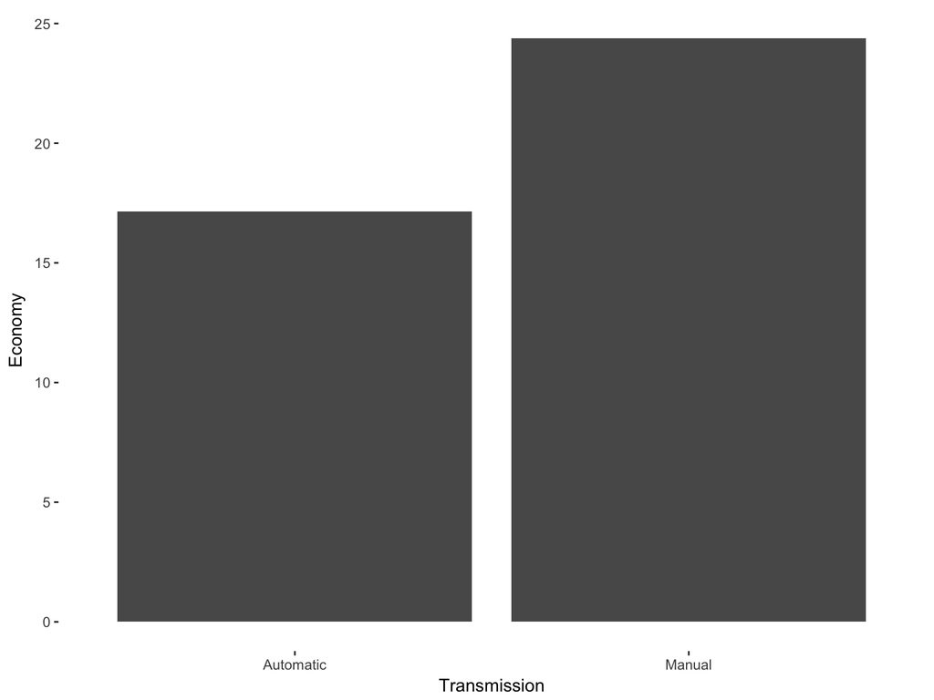

```r
economy_by_transmission <- data %>%
  group_by(Transmission) %>%
  summarise(Economy = mean(Economy))
bar_chart_transmission <- ggplot(economy_by_transmission, aes(Transmission, Economy)) + geom_col()
bar_chart_transmission
```

## Stacked bar chart

For a single quantitative and two categorical variables, bars can be stacked according the second categorical variable (here further mapped to colour hue):

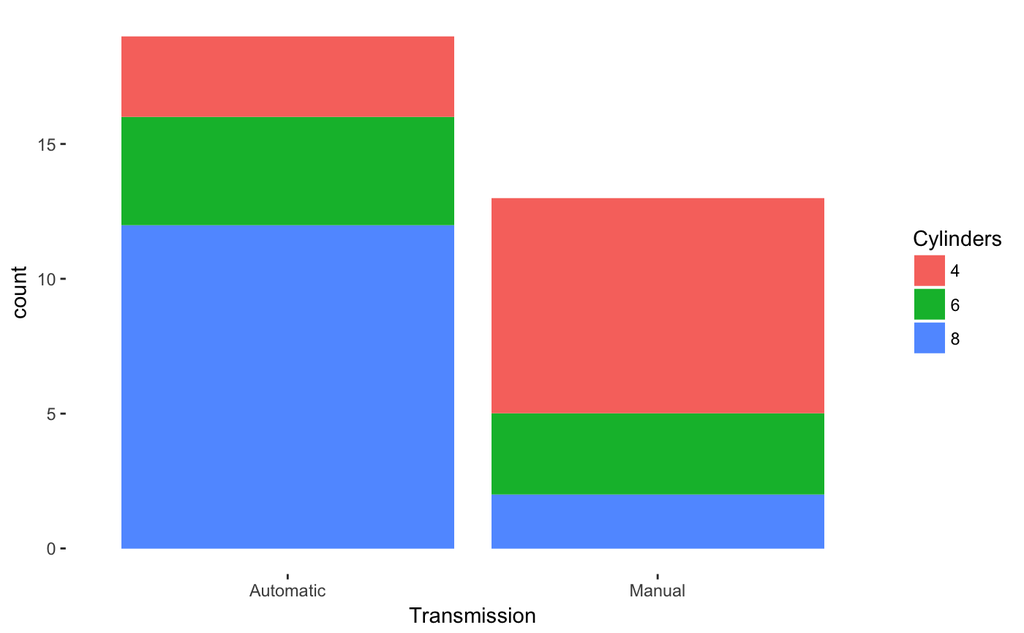

```r
count_by_transmission_and_Cylinders <- data %>%
  mutate(Cylinders = factor(Cylinders))
stacked_bar_chart_count <- ggplot(count_by_transmission_and_Cylinders, aes(Transmission)) + geom_bar(aes(fill = Cylinders))
stacked_bar_chart_count
```

The bottom-most bar (blue) is most effective in visual comparison tasks, because their length is mapped to a common scale. It is more difficult to accurately judge the difference in height of the green and orange bars.

Also note that stacked bar charts make no sense for stats that cannot be summed, such as the average economy of cars:

```r
economy_by_transmission_and_Cylinders <- data %>%
  mutate(Cylinders = factor(Cylinders)) %>%
  group_by(Transmission, Cylinders) %>%
  summarise(Economy = mean(Economy))
stacked_bar_chart_economy <- ggplot(economy_by_transmission_and_Cylinders, aes(Transmission, Economy)) + geom_col(aes(fill = Cylinders))
stacked_bar_chart_economy
```

[output not shown]

In order to get a better sense of the *proportions* of categories, the height of the bars can be normalized to create normalized stacked bar charts:

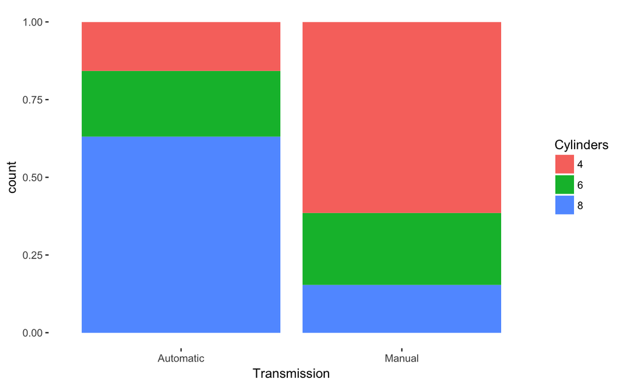

```r
normalized_stacked_bar_chart <- ggplot(count_by_transmission_and_Cylinders, aes(Transmission)) + geom_bar(aes(fill = Cylinders), position = "fill")
normalized_stacked_bar_chart
```

Note that each normalized stacked bar corresponds to a Cartesian version of a pie chart (but is more effective in conveying the data):

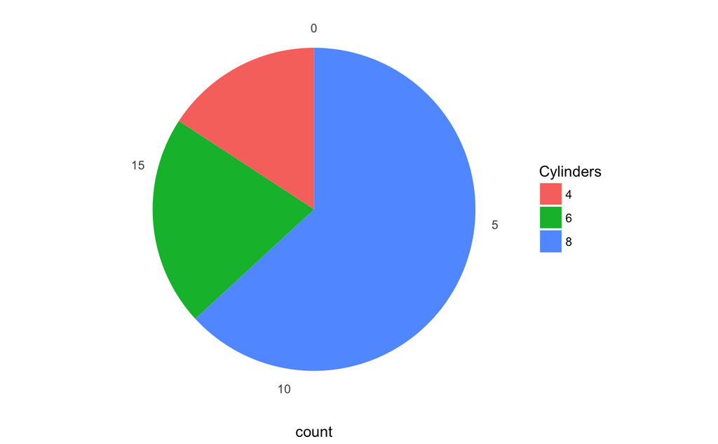

```r
pie_chart_automatic <- ggplot(filter(count_by_transmission_and_Cylinders, Transmission == "Automatic"), aes(x = factor(1), fill = Cylinders)) + geom_bar(width=1) + coord_polar(theta = "y") + theme(axis.title.y = element_blank(), axis.ticks.y = element_blank(), axis.text.y = element_blank())
pie_chart_automatic
```

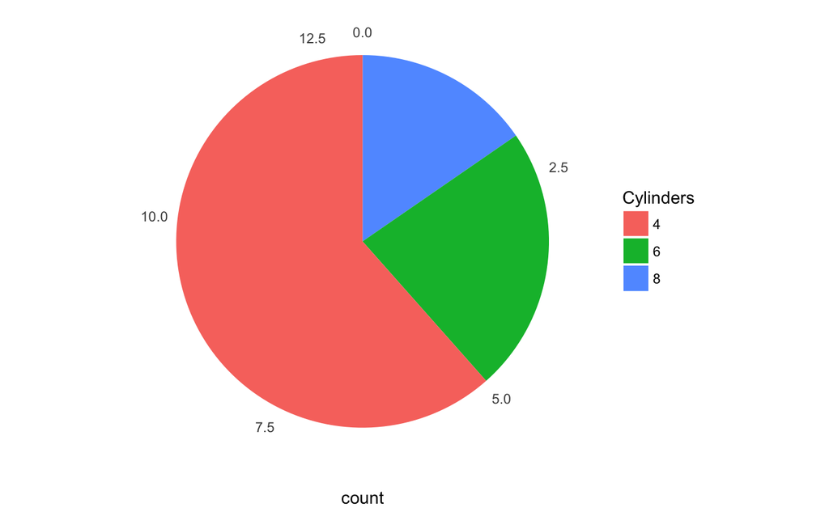

```r
pie_chart_manual <- ggplot(filter(count_by_transmission_and_Cylinders, Transmission == "Manual"), aes(x = factor(1), fill = Cylinders)) + geom_bar(width=1) + coord_polar(theta = "y") + theme(axis.title.y = element_blank(), axis.ticks.y = element_blank(), axis.text.y = element_blank())
pie_chart_manual
```

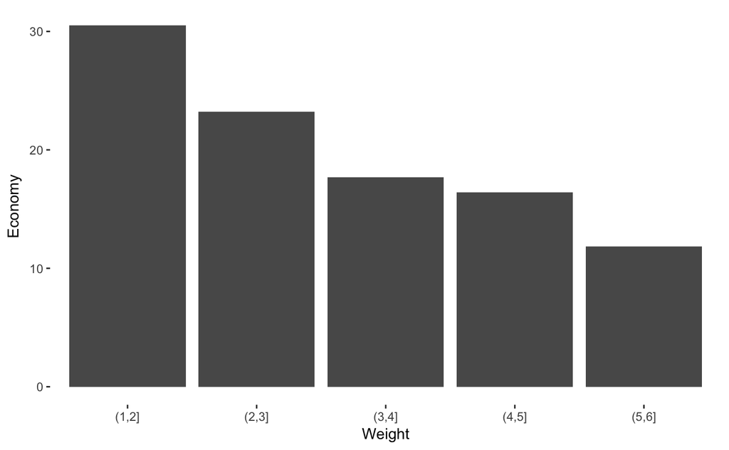

```r
economy_by_weight <- data %>%
  mutate(Weight = cut(Weight, c(seq(1,6)))) %>%
  group_by(Weight) %>%
  summarise(Economy = mean(Economy))
bar_chart_weight <- ggplot(economy_by_weight, aes(Weight, Economy)) + geom_col()
bar_chart_weight
```

## Line Charts

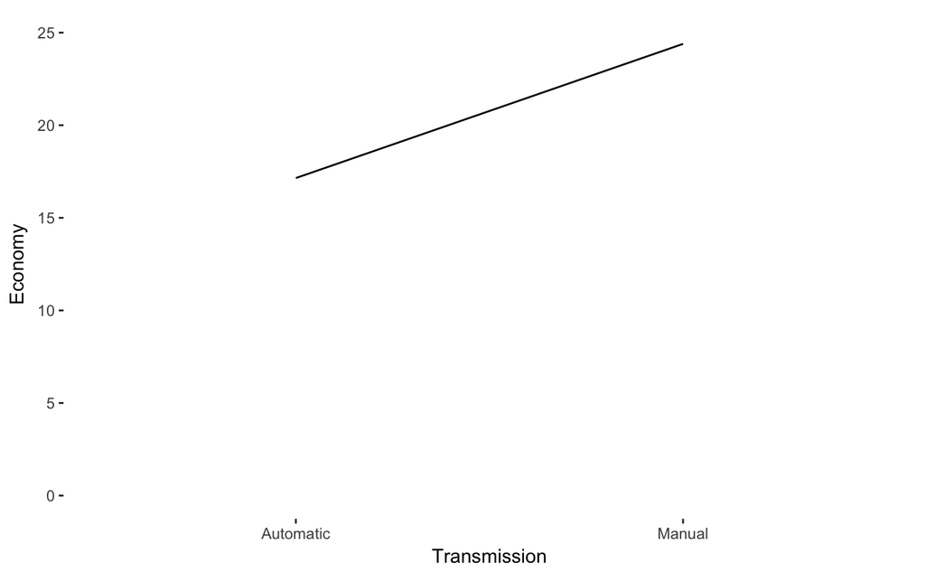

```r
line_chart_transmission <- ggplot(economy_by_transmission, aes(Transmission, Economy, group=1)) + geom_line() + ylim(0,25)
line_chart_transmission
```

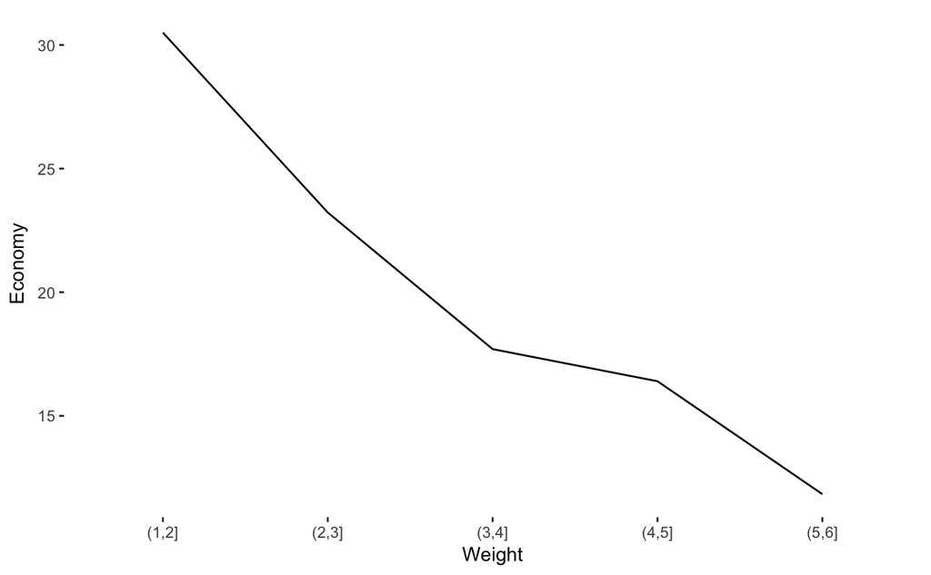

```r
line_chart_weight <- ggplot(economy_by_weight, aes(Weight, Economy, group=1)) + geom_line()
line_chart_weight
```